# Optimal Fitness Center Times

```r
library(tidyverse)

library(DT)

library(pander)

library(readr)

library(mosaic)

library(car)
#package to help you with dates:
library(lubridate)
```

```r
#Remove later, importing data
#possible questions: are times people check associated with different days of the week? Do more people check in on the weekends? When is the optimal time to go to the gym? etc.

#Official question: Is time of check-in associated with the day of the week and time of day (period)?
#Use an anova or krusial. 2 way.

#See warp breaks to get an idea

FitCenter1_13 <- read_csv("../Data/6.1-6.13FitCenter.csv")
FitCenter14_21 <- read_csv("../Data/6.14-6.21FitCenter.csv")
FitCenter22_29 <- read_csv("../Data/6.22-6.29FitCenter.csv")

FitCenterJune<- bind_rows(FitCenter1_13,FitCenter14_21,FitCenter22_29)

#FitCenterAdj<- FitCenterJune %>%
#group_by(Periods, Weekday) %>%
 # summarise(NumberOfPeople= sum(Quantity))

FitCenter <- read_csv("../Data/Final data.csv")
SuFit <- read_csv("../Data/Finaldatadraft one.csv")
```

## Optimal Gym Time

#### Background

The fitness center at BYU- I is popular and busy. There are lots of students who want to go and strength train, or maybe use the treadmill instead of running on the track. However, more often then not, there are so many people there that it’s hard to get a chance to use that bench press or to find an open tread mill. There is a solution! Wake up real early (4 or 5) and head on over to the gym. Then no one will be there and you’ll have the place pretty much all to your self. This isn’t a very popular fix. People like their sleep and generally aren’t responsible enough to get to bed on time. There is another way. There are certain times in the day when less people go to the gym. The trick is finding when they are.

## Analysis

#### Hypotheses

This Analysis will be using a two way ANOVA. Our factors are the weekday and the time period. We will be comparing these factors to the number of people at the fitness center.

1. Does the day of the week affect the average number of people?

Factor: Weekday with the levels being the Weekdays.

$$H_0: \mu_{Mon} = \mu_{Tus} = \mu_{Wed} = \mu_{thu} = \mu_{Fri} = \mu_{Sat} = \mu_{Sun}$$
$$H_a: \mu_{Mon} \neq \mu_{Tus} \neq \mu_{Wed} \neq \mu_{thu} \neq \mu_{Fri} \neq \mu_{Sat} \neq \mu_{Sun}$$

2. Does the time of day affect the average number of people?

Factor: Period with levels being different generally used time categories.

3. Does the effect of the time of day change for different days of the week? (Does the effect of Weekdays change for different levels of the time of day?) To put it another way, is there an interaction with the weekdays, and the time of day?

$$H_0: \text{The effect of the time of day is the same for differnt week days}$$

$$H_a: \text{The effect of the time of day is the same for differnt week days}$$
We will use a significance level of $\alpha=0.05$.

## Two Way ANOVA

For our analysis we will be using the following two way ANOVA.

```r
Optimal.aov <- aov(Quantity ~ as.factor(Weekday) + as.factor(DayTime) + as.factor(Weekday):as.factor(DayTime), data=FitCenter)

summary(Optimal.aov) %>% pander()
```

Analysis of Variance Model (continued below)

|  | Df | Sum Sq | Mean Sq | F value |
| --- | --- | --- | --- | --- |
| **as.factor(Weekday)** | 6 | 858357 | 143060 | 4.384 |
| **as.factor(DayTime)** | 7 | 4253386 | 607627 | 18.62 |
| **as.factor(Weekday):as.factor(DayTime)** | 35 | 606671 | 17333 | 0.5312 |
| **Residuals** | 97 | 3165369 | 32633 | NA |

|  | Pr(>F) |
| --- | --- |
| **as.factor(Weekday)** | 0.0005827 |
| **as.factor(DayTime)** | 1.596e-15 |
| **as.factor(Weekday):as.factor(DayTime)** | 0.982 |
| **Residuals** | NA |

Looking at our p-values from our test we can conclude that:

1. The weekday is a significant factor of the quantity of people
2. The time of day is also a significant factor
3. The time of day, and the weekday don’t have a significant interaction with each other.

#### Requirments

Looking at our plots we can see that our data is no good for an ANOVA test. The QQplot on the right shows us that our data is skewed, and the residuals plot on the left shows us that we don’t have constant variance. It appears to resemble an exponential curve. This means that our results can’t be considered valid.

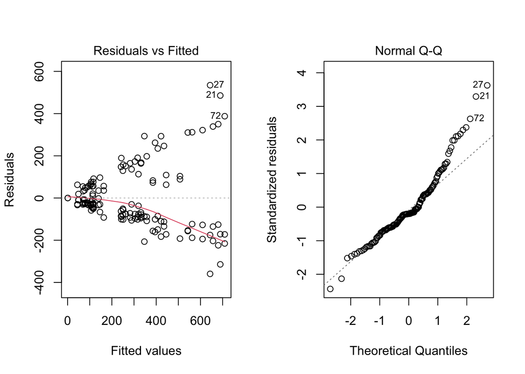

```r
par(mfrow = c(1,2))
plot(Optimal.aov, which = 1:2)
```

## Conclusions

Even though our test failed we can still draw a lot of conclusions from just a few graphs.

#### Weekdays

Looking at these box plot we can see the spread of our data better. Box plots are summarizing data, and because of this are prone to being inaccurate from outliers. To solve this I added in the data points so that we can see them along the spread of each category.

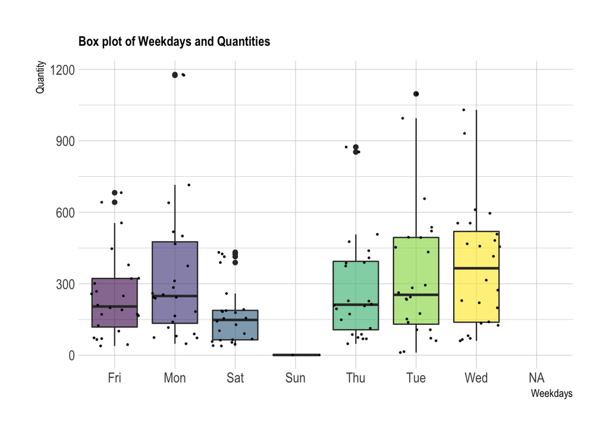

```r
# Libraries
library(tidyverse)
library(hrbrthemes)
library(viridis)

# Plot
FitCenter %>%
  ggplot( aes(x=Weekday, y=Quantity, fill=Weekday)) +
    geom_boxplot() +
    scale_fill_viridis(discrete = TRUE, alpha=0.6) +
    geom_jitter(color="black", size=0.4, alpha=0.9) +
    theme_ipsum() +
    theme(
      legend.position="none",
      plot.title = element_text(size=11)
    ) +
    ggtitle("Box plot of Weekdays and Quantities") +
    xlab("Weekdays")
```

We can aslo see that Saturday has a significantly lower median in-spite of strong upward trending outliers.

In summary we can conclude that the least busy day to go to the gym would be Saturday (Sunday the Gym is closed), and the most busy would be Wednesday.

#### DayTimes

This bar chart shows us the times people check in.

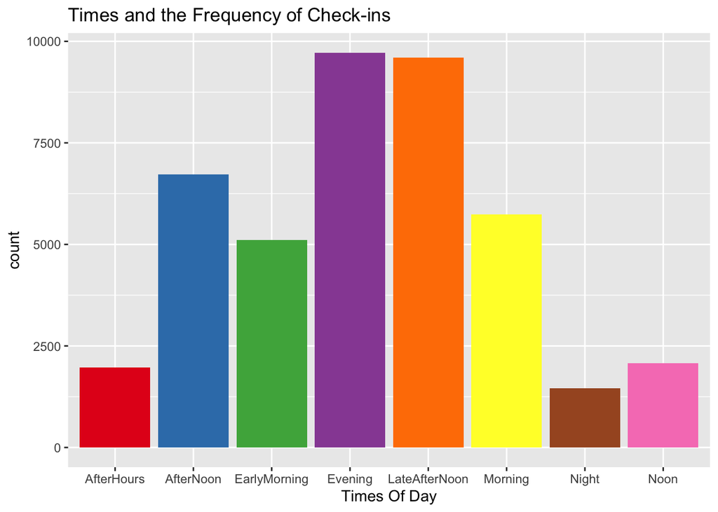

```r
ggplot(FitCenterJune, aes(as.factor(Periods), fill= as.factor(Periods))) +
  geom_bar( ) +
  scale_fill_brewer(palette = "Set1") +
  theme(legend.position="none") +
  labs(x="Times Of Day")+
    ggtitle("Times and the Frequency of Check-ins")
```

Looking at the chart we can see that the Fitness Center is the least busy at night. It’s more busy in the Fitness Center after hours then it is at night. That’s a little confusing. We can aslo see the worst time to go is in the evening or late afternoon.

## Final Thoughts

It has taken a lot to get to this point, and there is so much further to go. We know that this data isn’t completely reliable. However, by looking at the data as a whole we are able to get an idea of what days people are going to the gym. Due to technical difficulties we only have one month of data. There is so much more out there that we can begin to test and make use of. Let’s see where this all goes.